# Risk Factor Analysis

## Outcome Variable

**Outcome Variable:** y_rate_haz

## Predictor Variables

**Intervention Variable:** parity

**Adjustment Set:**

- arm
- W_mage
- meducyrs
- feducyrs
- hhwealth_quart
- hfoodsec
- W_mhtcm
- vagbrth
- W_nrooms
- impfloor
- impsan
- safeh20
- delta_W_mage
- delta_meducyrs
- delta_feducyrs
- delta_hhwealth_quart
- delta_hfoodsec
- delta_W_mhtcm
- delta_vagbrth
- delta_W_nrooms
- delta_impfloor
- delta_impsan
- delta_safeh20

## Stratifying Variables

The analysis was stratified on these variable(s):

- agecat
- studyid
- country

## Data Summary

| agecat | studyid | country | parity | n_cell | n |
| --- | --- | --- | --- | --- | --- |
| 0-3 months | ki1000304b-SAS-CompFeed | INDIA | 1 | 313 | 1168 |
| 0-3 months | ki1000304b-SAS-CompFeed | INDIA | 2 | 280 | 1168 |
| 0-3 months | ki1000304b-SAS-CompFeed | INDIA | 3+ | 575 | 1168 |
| 0-3 months | ki1017093b-PROVIDE | BANGLADESH | 1 | 240 | 634 |
| 0-3 months | ki1017093b-PROVIDE | BANGLADESH | 2 | 225 | 634 |
| 0-3 months | ki1017093b-PROVIDE | BANGLADESH | 3+ | 169 | 634 |
| 0-3 months | ki1101329-Keneba | GAMBIA | 1 | 130 | 1145 |
| 0-3 months | ki1101329-Keneba | GAMBIA | 2 | 113 | 1145 |
| 0-3 months | ki1101329-Keneba | GAMBIA | 3+ | 902 | 1145 |
| 0-3 months | ki1126311-ZVITAMBO | ZIMBABWE | 1 | 3052 | 7863 |
| 0-3 months | ki1126311-ZVITAMBO | ZIMBABWE | 2 | 2438 | 7863 |
| 0-3 months | ki1126311-ZVITAMBO | ZIMBABWE | 3+ | 2373 | 7863 |
| 0-3 months | ki1135781-COHORTS | GUATEMALA | 1 | 93 | 728 |
| 0-3 months | ki1135781-COHORTS | GUATEMALA | 2 | 111 | 728 |
| 0-3 months | ki1135781-COHORTS | GUATEMALA | 3+ | 524 | 728 |
| 0-3 months | ki1135781-COHORTS | INDIA | 1 | 671 | 4021 |
| 0-3 months | ki1135781-COHORTS | INDIA | 2 | 1015 | 4021 |
| 0-3 months | ki1135781-COHORTS | INDIA | 3+ | 2335 | 4021 |
| 0-3 months | kiGH5241-JiVitA-3 | BANGLADESH | 1 | 12750 | 40056 |
| 0-3 months | kiGH5241-JiVitA-3 | BANGLADESH | 2 | 13890 | 40056 |
| 0-3 months | kiGH5241-JiVitA-3 | BANGLADESH | 3+ | 13416 | 40056 |
| 3-6 months | ki1000304b-SAS-CompFeed | INDIA | 1 | 299 | 1124 |
| 3-6 months | ki1000304b-SAS-CompFeed | INDIA | 2 | 261 | 1124 |
| 3-6 months | ki1000304b-SAS-CompFeed | INDIA | 3+ | 564 | 1124 |
| 3-6 months | ki1017093b-PROVIDE | BANGLADESH | 1 | 206 | 574 |
| 3-6 months | ki1017093b-PROVIDE | BANGLADESH | 2 | 211 | 574 |
| 3-6 months | ki1017093b-PROVIDE | BANGLADESH | 3+ | 157 | 574 |
| 3-6 months | ki1066203-TanzaniaChild2 | TANZANIA, UNITED REPUBLIC OF | 1 | 566 | 1637 |
| 3-6 months | ki1066203-TanzaniaChild2 | TANZANIA, UNITED REPUBLIC OF | 2 | 536 | 1637 |
| 3-6 months | ki1066203-TanzaniaChild2 | TANZANIA, UNITED REPUBLIC OF | 3+ | 535 | 1637 |

[output cut: 78 more lines]

The following strata were considered:

- agecat: 0-3 months, studyid: ki1000304b-SAS-CompFeed, country: INDIA
- agecat: 0-3 months, studyid: ki1017093b-PROVIDE, country: BANGLADESH
- agecat: 0-3 months, studyid: ki1101329-Keneba, country: GAMBIA
- agecat: 0-3 months, studyid: ki1126311-ZVITAMBO, country: ZIMBABWE
- agecat: 0-3 months, studyid: ki1135781-COHORTS, country: GUATEMALA
- agecat: 0-3 months, studyid: ki1135781-COHORTS, country: INDIA
- agecat: 0-3 months, studyid: kiGH5241-JiVitA-3, country: BANGLADESH
- agecat: 12-24 months, studyid: ki1017093b-PROVIDE, country: BANGLADESH
- agecat: 12-24 months, studyid: ki1066203-TanzaniaChild2, country: TANZANIA, UNITED REPUBLIC OF
- agecat: 12-24 months, studyid: ki1101329-Keneba, country: GAMBIA
- agecat: 12-24 months, studyid: ki1113344-GMS-Nepal, country: NEPAL
- agecat: 12-24 months, studyid: ki1126311-ZVITAMBO, country: ZIMBABWE
- agecat: 12-24 months, studyid: ki1135781-COHORTS, country: GUATEMALA
- agecat: 12-24 months, studyid: ki1135781-COHORTS, country: INDIA
- agecat: 12-24 months, studyid: ki1135781-COHORTS, country: PHILIPPINES
- agecat: 12-24 months, studyid: kiGH5241-JiVitA-3, country: BANGLADESH
- agecat: 3-6 months, studyid: ki1000304b-SAS-CompFeed, country: INDIA
- agecat: 3-6 months, studyid: ki1017093b-PROVIDE, country: BANGLADESH
- agecat: 3-6 months, studyid: ki1066203-TanzaniaChild2, country: TANZANIA, UNITED REPUBLIC OF
- agecat: 3-6 months, studyid: ki1101329-Keneba, country: GAMBIA
- agecat: 3-6 months, studyid: ki1113344-GMS-Nepal, country: NEPAL
- agecat: 3-6 months, studyid: ki1126311-ZVITAMBO, country: ZIMBABWE
- agecat: 3-6 months, studyid: ki1135781-COHORTS, country: GUATEMALA
- agecat: 3-6 months, studyid: ki1135781-COHORTS, country: INDIA
- agecat: 3-6 months, studyid: kiGH5241-JiVitA-3, country: BANGLADESH
- agecat: 6-12 months, studyid: ki1000304b-SAS-CompFeed, country: INDIA
- agecat: 6-12 months, studyid: ki1000304b-SAS-FoodSuppl, country: INDIA
- agecat: 6-12 months, studyid: ki1017093b-PROVIDE, country: BANGLADESH
- agecat: 6-12 months, studyid: ki1066203-TanzaniaChild2, country: TANZANIA, UNITED REPUBLIC OF
- agecat: 6-12 months, studyid: ki1101329-Keneba, country: GAMBIA
- agecat: 6-12 months, studyid: ki1113344-GMS-Nepal, country: NEPAL
- agecat: 6-12 months, studyid: ki1126311-ZVITAMBO, country: ZIMBABWE
- agecat: 6-12 months, studyid: ki1135781-COHORTS, country: GUATEMALA
- agecat: 6-12 months, studyid: ki1135781-COHORTS, country: INDIA
- agecat: 6-12 months, studyid: ki1135781-COHORTS, country: PHILIPPINES
- agecat: 6-12 months, studyid: kiGH5241-JiVitA-3, country: BANGLADESH

### Dropped Strata

Some strata were dropped due to rare outcomes:

- agecat: 12-24 months, studyid: ki1066203-TanzaniaChild2, country: TANZANIA, UNITED REPUBLIC OF

## Methods Detail

We’re interested in the causal parameters $E[Y_a]$ for all values of $a \in \mathcal{A}$. These parameters represent the mean outcome if, possibly contrary to fact, we intervened to set all units to have $A=a$. Under the randomization and positivity assumptions, these are identified by the statistical parameters $\psi_a=E_W[E_{Y|A,W}(Y|A=a,W)]$. In addition, we’re interested in the mean of $Y$, $E[Y]$ under no intervention (the observed mean). We will estimate these parameters by using SuperLearner to fit the relevant likelihood factors – $E_{Y|A,W}(Y|A=a,W)$ and $p(A=a|W)$, and then updating our likelihood fit using a joint TMLE.

For unadjusted analyses ($W=\{\}$), initial likelihoods were estimated using Lrnr_glm to estimate the simple $E(Y|A)$ and Lrnr_mean to estimate $p(A)$. For adjusted analyses, a small library containing Lrnr_glmnet, Lrnr_xgboost, and Lrnr_mean was used.

Having estimated these parameters, we will then use the delta method to estimate relative risks and attributable risks relative to a prespecified baseline level of $A$.

# Results Detail

## Results Plots

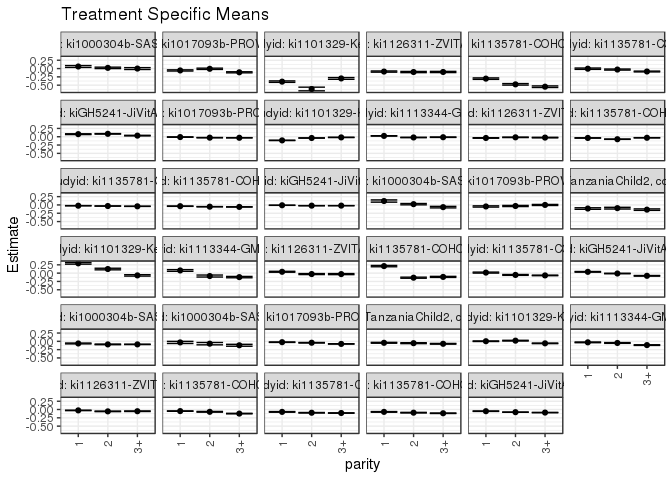

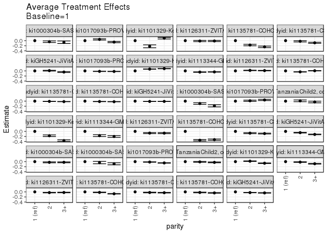

## Results Table

### Parameter: TSM

| agecat | studyid | country | intervention_level | baseline_level | estimate | ci_lower | ci_upper |
| --- | --- | --- | --- | --- | --- | --- | --- |
| 0-3 months | ki1000304b-SAS-CompFeed | INDIA | 1 | NA | 0.0615882 | 0.0337670 | 0.0894094 |
| 0-3 months | ki1000304b-SAS-CompFeed | INDIA | 2 | NA | 0.0207288 | -0.0002298 | 0.0416873 |
| 0-3 months | ki1000304b-SAS-CompFeed | INDIA | 3+ | NA | -0.0003472 | -0.0283251 | 0.0276307 |
| 0-3 months | ki1017093b-PROVIDE | BANGLADESH | 1 | NA | -0.0568374 | -0.0749615 | -0.0387132 |
| 0-3 months | ki1017093b-PROVIDE | BANGLADESH | 2 | NA | -0.0074060 | -0.0264798 | 0.0116678 |
| 0-3 months | ki1017093b-PROVIDE | BANGLADESH | 3+ | NA | -0.1127438 | -0.1293057 | -0.0961820 |
| 0-3 months | ki1101329-Keneba | GAMBIA | 1 | NA | -0.3943349 | -0.4158703 | -0.3727995 |
| 0-3 months | ki1101329-Keneba | GAMBIA | 2 | NA | -0.6155970 | -0.6711631 | -0.5600309 |
| 0-3 months | ki1101329-Keneba | GAMBIA | 3+ | NA | -0.2973835 | -0.3234921 | -0.2712748 |
| 0-3 months | ki1126311-ZVITAMBO | ZIMBABWE | 1 | NA | -0.0908257 | -0.1079560 | -0.0736954 |
| 0-3 months | ki1126311-ZVITAMBO | ZIMBABWE | 2 | NA | -0.1046931 | -0.1226389 | -0.0867472 |
| 0-3 months | ki1126311-ZVITAMBO | ZIMBABWE | 3+ | NA | -0.1032444 | -0.1205874 | -0.0859013 |
| 0-3 months | ki1135781-COHORTS | GUATEMALA | 1 | NA | -0.3031930 | -0.3243092 | -0.2820768 |
| 0-3 months | ki1135781-COHORTS | GUATEMALA | 2 | NA | -0.4757390 | -0.4982916 | -0.4531865 |
| 0-3 months | ki1135781-COHORTS | GUATEMALA | 3+ | NA | -0.5459794 | -0.5693487 | -0.5226101 |
| 0-3 months | ki1135781-COHORTS | INDIA | 1 | NA | -0.0046613 | -0.0239427 | 0.0146201 |
| 0-3 months | ki1135781-COHORTS | INDIA | 2 | NA | -0.0298948 | -0.0457636 | -0.0140259 |
| 0-3 months | ki1135781-COHORTS | INDIA | 3+ | NA | -0.0884451 | -0.1003800 | -0.0765102 |
| 0-3 months | kiGH5241-JiVitA-3 | BANGLADESH | 1 | NA | 0.0780568 | 0.0659909 | 0.0901226 |
| 0-3 months | kiGH5241-JiVitA-3 | BANGLADESH | 2 | NA | 0.0880495 | 0.0798812 | 0.0962179 |
| 0-3 months | kiGH5241-JiVitA-3 | BANGLADESH | 3+ | NA | 0.0337399 | 0.0248673 | 0.0426126 |
| 3-6 months | ki1000304b-SAS-CompFeed | INDIA | 1 | NA | 0.1176143 | 0.0843663 | 0.1508623 |
| 3-6 months | ki1000304b-SAS-CompFeed | INDIA | 2 | NA | 0.0235872 | 0.0037783 | 0.0433961 |
| 3-6 months | ki1000304b-SAS-CompFeed | INDIA | 3+ | NA | -0.0663232 | -0.0885567 | -0.0440897 |
| 3-6 months | ki1017093b-PROVIDE | BANGLADESH | 1 | NA | -0.0460179 | -0.0657579 | -0.0262778 |
| 3-6 months | ki1017093b-PROVIDE | BANGLADESH | 2 | NA | -0.0320306 | -0.0485554 | -0.0155059 |
| 3-6 months | ki1017093b-PROVIDE | BANGLADESH | 3+ | NA | -0.0002266 | -0.0162444 | 0.0157911 |
| 3-6 months | ki1066203-TanzaniaChild2 | TANZANIA, UNITED REPUBLIC OF | 1 | NA | -0.1080215 | -0.1307622 | -0.0852808 |
| 3-6 months | ki1066203-TanzaniaChild2 | TANZANIA, UNITED REPUBLIC OF | 2 | NA | -0.0966687 | -0.1223076 | -0.0710298 |
| 3-6 months | ki1066203-TanzaniaChild2 | TANZANIA, UNITED REPUBLIC OF | 3+ | NA | -0.1414240 | -0.1639928 | -0.1188552 |

[output cut: 75 more lines]

### Parameter: E(Y)

| agecat | studyid | country | intervention_level | baseline_level | estimate | ci_lower | ci_upper |
| --- | --- | --- | --- | --- | --- | --- | --- |
| 0-3 months | ki1000304b-SAS-CompFeed | INDIA | NA | NA | 0.0123467 | -0.0036133 | 0.0283068 |
| 0-3 months | ki1017093b-PROVIDE | BANGLADESH | NA | NA | -0.0413143 | -0.0594662 | -0.0231624 |
| 0-3 months | ki1101329-Keneba | GAMBIA | NA | NA | -0.2853220 | -0.3108085 | -0.2598355 |
| 0-3 months | ki1126311-ZVITAMBO | ZIMBABWE | NA | NA | -0.1428480 | -0.1532568 | -0.1324391 |
| 0-3 months | ki1135781-COHORTS | GUATEMALA | NA | NA | -0.5431999 | -0.5652020 | -0.5211979 |
| 0-3 months | ki1135781-COHORTS | INDIA | NA | NA | -0.0684794 | -0.0774008 | -0.0595580 |
| 0-3 months | kiGH5241-JiVitA-3 | BANGLADESH | NA | NA | 0.0705478 | 0.0655933 | 0.0755023 |
| 3-6 months | ki1000304b-SAS-CompFeed | INDIA | NA | NA | -0.0166348 | -0.0360336 | 0.0027639 |
| 3-6 months | ki1017093b-PROVIDE | BANGLADESH | NA | NA | -0.0272428 | -0.0436954 | -0.0107902 |
| 3-6 months | ki1066203-TanzaniaChild2 | TANZANIA, UNITED REPUBLIC OF | NA | NA | -0.0841486 | -0.1008599 | -0.0674373 |
| 3-6 months | ki1101329-Keneba | GAMBIA | NA | NA | -0.0278645 | -0.0482582 | -0.0074707 |
| 3-6 months | ki1113344-GMS-Nepal | NEPAL | NA | NA | -0.1659967 | -0.1845182 | -0.1474752 |
| 3-6 months | ki1126311-ZVITAMBO | ZIMBABWE | NA | NA | -0.0009676 | -0.0102953 | 0.0083602 |
| 3-6 months | ki1135781-COHORTS | GUATEMALA | NA | NA | -0.0963382 | -0.1109683 | -0.0817082 |
| 3-6 months | ki1135781-COHORTS | INDIA | NA | NA | -0.0633737 | -0.0703095 | -0.0564379 |
| 3-6 months | kiGH5241-JiVitA-3 | BANGLADESH | NA | NA | -0.0034446 | -0.0083108 | 0.0014217 |
| 6-12 months | ki1000304b-SAS-CompFeed | INDIA | NA | NA | -0.0862318 | -0.0909003 | -0.0815633 |
| 6-12 months | ki1000304b-SAS-FoodSuppl | INDIA | NA | NA | -0.1077712 | -0.1389671 | -0.0765754 |
| 6-12 months | ki1017093b-PROVIDE | BANGLADESH | NA | NA | -0.0626151 | -0.0695574 | -0.0556729 |
| 6-12 months | ki1066203-TanzaniaChild2 | TANZANIA, UNITED REPUBLIC OF | NA | NA | -0.0592743 | -0.0685477 | -0.0500010 |
| 6-12 months | ki1101329-Keneba | GAMBIA | NA | NA | -0.0627772 | -0.0712590 | -0.0542954 |
| 6-12 months | ki1113344-GMS-Nepal | NEPAL | NA | NA | -0.0614960 | -0.0697225 | -0.0532696 |
| 6-12 months | ki1126311-ZVITAMBO | ZIMBABWE | NA | NA | -0.0492642 | -0.0539207 | -0.0446077 |
| 6-12 months | ki1135781-COHORTS | GUATEMALA | NA | NA | -0.1091173 | -0.1161782 | -0.1020564 |
| 6-12 months | ki1135781-COHORTS | INDIA | NA | NA | -0.0957304 | -0.1001246 | -0.0913361 |
| 6-12 months | ki1135781-COHORTS | PHILIPPINES | NA | NA | -0.0999391 | -0.1050516 | -0.0948266 |
| 6-12 months | kiGH5241-JiVitA-3 | BANGLADESH | NA | NA | -0.0748654 | -0.0777070 | -0.0720238 |
| 12-24 months | ki1017093b-PROVIDE | BANGLADESH | NA | NA | -0.0081718 | -0.0120131 | -0.0043304 |
| 12-24 months | ki1101329-Keneba | GAMBIA | NA | NA | -0.0201573 | -0.0242768 | -0.0160377 |
| 12-24 months | ki1113344-GMS-Nepal | NEPAL | NA | NA | -0.0155649 | -0.0206065 | -0.0105234 |
| 12-24 months | ki1126311-ZVITAMBO | ZIMBABWE | NA | NA | -0.0517435 | -0.0609232 | -0.0425638 |
| 12-24 months | ki1135781-COHORTS | GUATEMALA | NA | NA | -0.0295389 | -0.0332082 | -0.0258696 |
| 12-24 months | ki1135781-COHORTS | INDIA | NA | NA | -0.0374666 | -0.0395050 | -0.0354283 |
| 12-24 months | ki1135781-COHORTS | PHILIPPINES | NA | NA | -0.0576520 | -0.0601763 | -0.0551277 |
| 12-24 months | kiGH5241-JiVitA-3 | BANGLADESH | NA | NA | -0.0188143 | -0.0206609 | -0.0169677 |

### Parameter: ATE

| agecat | studyid | country | intervention_level | baseline_level | estimate | ci_lower | ci_upper |
| --- | --- | --- | --- | --- | --- | --- | --- |
| 0-3 months | ki1000304b-SAS-CompFeed | INDIA | 1 | 1 | 0.0000000 | 0.0000000 | 0.0000000 |
| 0-3 months | ki1000304b-SAS-CompFeed | INDIA | 2 | 1 | -0.0408594 | -0.0735183 | -0.0082006 |
| 0-3 months | ki1000304b-SAS-CompFeed | INDIA | 3+ | 1 | -0.0619354 | -0.1121644 | -0.0117064 |
| 0-3 months | ki1017093b-PROVIDE | BANGLADESH | 1 | 1 | 0.0000000 | 0.0000000 | 0.0000000 |
| 0-3 months | ki1017093b-PROVIDE | BANGLADESH | 2 | 1 | 0.0494314 | 0.0250159 | 0.0738469 |
| 0-3 months | ki1017093b-PROVIDE | BANGLADESH | 3+ | 1 | -0.0559065 | -0.0788984 | -0.0329145 |
| 0-3 months | ki1101329-Keneba | GAMBIA | 1 | 1 | 0.0000000 | 0.0000000 | 0.0000000 |
| 0-3 months | ki1101329-Keneba | GAMBIA | 2 | 1 | -0.2212621 | -0.2784517 | -0.1640725 |
| 0-3 months | ki1101329-Keneba | GAMBIA | 3+ | 1 | 0.0969514 | 0.0645872 | 0.1293157 |
| 0-3 months | ki1126311-ZVITAMBO | ZIMBABWE | 1 | 1 | 0.0000000 | 0.0000000 | 0.0000000 |
| 0-3 months | ki1126311-ZVITAMBO | ZIMBABWE | 2 | 1 | -0.0138674 | -0.0384446 | 0.0107099 |
| 0-3 months | ki1126311-ZVITAMBO | ZIMBABWE | 3+ | 1 | -0.0124187 | -0.0367371 | 0.0118998 |
| 0-3 months | ki1135781-COHORTS | GUATEMALA | 1 | 1 | 0.0000000 | 0.0000000 | 0.0000000 |
| 0-3 months | ki1135781-COHORTS | GUATEMALA | 2 | 1 | -0.1725460 | -0.2012916 | -0.1438005 |
| 0-3 months | ki1135781-COHORTS | GUATEMALA | 3+ | 1 | -0.2427864 | -0.2727597 | -0.2128130 |
| 0-3 months | ki1135781-COHORTS | INDIA | 1 | 1 | 0.0000000 | 0.0000000 | 0.0000000 |
| 0-3 months | ki1135781-COHORTS | INDIA | 2 | 1 | -0.0252334 | -0.0500990 | -0.0003679 |
| 0-3 months | ki1135781-COHORTS | INDIA | 3+ | 1 | -0.0837838 | -0.1063916 | -0.0611760 |
| 0-3 months | kiGH5241-JiVitA-3 | BANGLADESH | 1 | 1 | 0.0000000 | 0.0000000 | 0.0000000 |
| 0-3 months | kiGH5241-JiVitA-3 | BANGLADESH | 2 | 1 | 0.0099928 | -0.0042688 | 0.0242544 |
| 0-3 months | kiGH5241-JiVitA-3 | BANGLADESH | 3+ | 1 | -0.0443168 | -0.0595369 | -0.0290968 |
| 3-6 months | ki1000304b-SAS-CompFeed | INDIA | 1 | 1 | 0.0000000 | 0.0000000 | 0.0000000 |
| 3-6 months | ki1000304b-SAS-CompFeed | INDIA | 2 | 1 | -0.0940271 | -0.1270942 | -0.0609600 |
| 3-6 months | ki1000304b-SAS-CompFeed | INDIA | 3+ | 1 | -0.1839375 | -0.2281530 | -0.1397219 |
| 3-6 months | ki1017093b-PROVIDE | BANGLADESH | 1 | 1 | 0.0000000 | 0.0000000 | 0.0000000 |
| 3-6 months | ki1017093b-PROVIDE | BANGLADESH | 2 | 1 | 0.0139872 | -0.0102504 | 0.0382249 |
| 3-6 months | ki1017093b-PROVIDE | BANGLADESH | 3+ | 1 | 0.0457912 | 0.0220838 | 0.0694987 |
| 3-6 months | ki1066203-TanzaniaChild2 | TANZANIA, UNITED REPUBLIC OF | 1 | 1 | 0.0000000 | 0.0000000 | 0.0000000 |
| 3-6 months | ki1066203-TanzaniaChild2 | TANZANIA, UNITED REPUBLIC OF | 2 | 1 | 0.0113528 | -0.0223278 | 0.0450334 |
| 3-6 months | ki1066203-TanzaniaChild2 | TANZANIA, UNITED REPUBLIC OF | 3+ | 1 | -0.0334025 | -0.0651106 | -0.0016944 |

[output cut: 75 more lines]